# Why Are Bank Customers Leaving? A Churn Analysis

Author

Areej Bahar

## The business problem

A bank is losing about 1 in 5 customers (20.4% churn). Winning a new customer costs far more than keeping an existing one, so the question is: **who is leaving, and what should the bank do about it?**

## Data and method

- Data: 10,000 bank customers (Kaggle “Churn Modelling” dataset), with age, country, products held, activity status and whether the customer left.
- Cleaned and prepared in R (tidyverse), then analysed with SQL in MySQL Workbench, and charted in R (ggplot2).
- Code is in the `scripts` folder of this repository.

## Findings

### 1. Customers with one product drive most of the churn, and 3+ products is a red flag

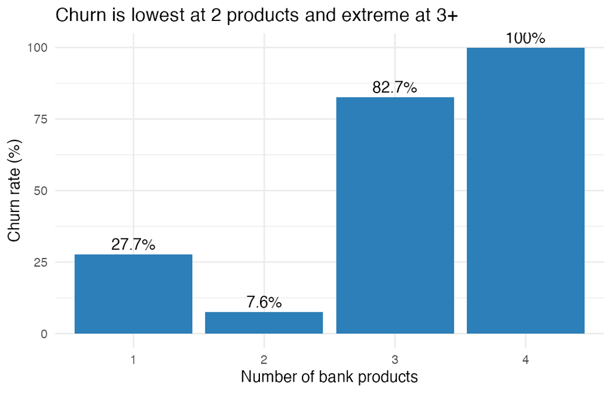

Churn by number of products

Customers with two products are the most loyal (7.6% churn). Single-product customers leave at 27.7% and make up roughly 69% of all churn. Almost everyone holding three or four products left, although that is a small group (326 customers).

### 2. Inactive members leave at nearly twice the rate of active ones

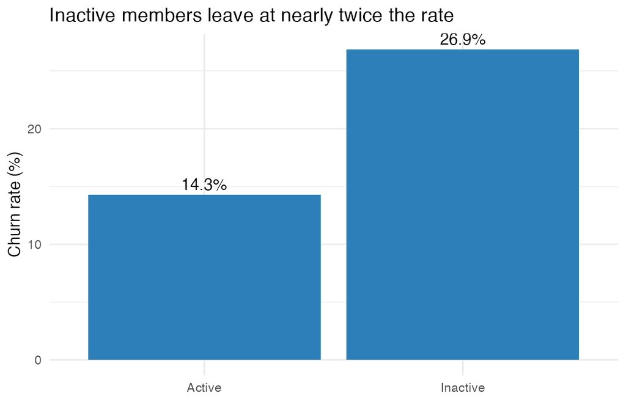

Churn by activity

Inactive members churn at 26.9% versus 14.3% for active members. They are about 48% of customers but roughly 64% of all churn.

### 3. Customers aged 40-59 are the most likely to leave

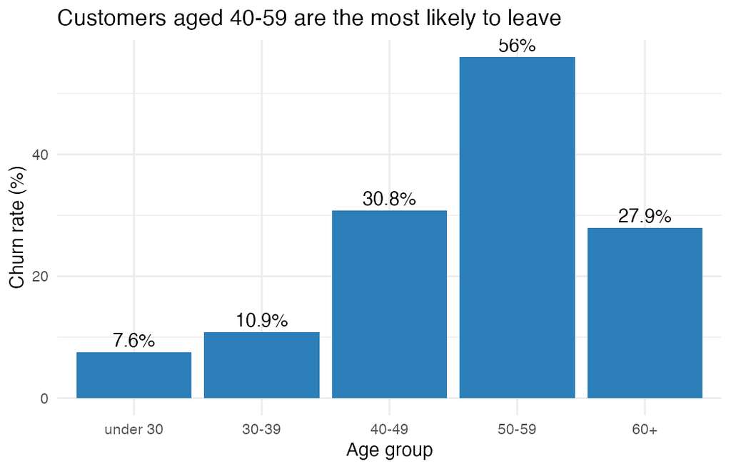

Churn by age group

Churn peaks at 56% for ages 50-59 and 30.8% for ages 40-49. Together these groups are about 35% of customers but roughly 63% of churn.

### Supporting finding: Germany

Germany has a churn rate of 32.4%, about double Spain (16.7%) and France (16.2%). It has a quarter of the customers but about 40% of the churn.

## Recommendations

1. **Re-engage inactive members before they leave**, for example with a call or offer when activity drops.
2. **Investigate why customers with 3+ products leave.** Check fees, product bundling and how these products are sold.
3. **Pilot a second-product offer for single-product customers** and measure whether churn falls.
4. **Prioritise retention efforts for customers aged 40-59 and in Germany.**

## Limitations

- This is a snapshot, so the findings show association, not cause. For example, holding two products may not itself reduce churn, which is why the second-product idea is a pilot.
- There is no revenue data, so the dollar value of these recommendations cannot be estimated.
- The 3+ product group is small, so those rates are less stable.